# Peer Health Shocks and Labor Supply

Guest Lecture for ECON 3100

Joshua C. Martin

joshua.martin@vanderbilt.edu

Vanderbilt University

October 15, 2024

## Worker Productivity in Sports

1. What is the **one-word term** associated with the usage of “sabermetrics” for identifying **undervalued workers** in sports settings?
   - Hint: This term originates from the title of the 2003 biographical novel of a (sports) General Manager and was later adapted into a 2011 Academy Award-nominated film.
   - What are the **names of the two lead actors** staring in the aforementioned film?
2. What **sport** was this approach initially most famously associated with?
   - “Sabermetrics” was originally written as “SABRmetrics”. What does “**SABR**” stand for?

## Musical Interlude

[video not shown]

## Worker Productivity in Sports

3. What is the **name** of the individual credited with creation of “Moneyball”?
   - This individual graduated with degrees in what **two subjects**?
4. What commonly-used **concept** from Labor Economics most closely approximates workers’ “Approximate Value”?

[video not shown]

## Musical Interlude

[video not shown]

## Worker Productivity in Sports

5. If team sizes are fixed, what **margin** are we referring to with respect to $MP_L$?
6. Thinking like an economist, list **five distinct factors changing individual productivity** in this setting.
- Going forward, let worker **productivity** be represented by $\upsilon$
  - Constructed such that the value of a replacement worker is equal to zero
7. Draw the relationship between $\upsilon$ and age

## Worker Productivity in Sports

### Productivity and Age (Q. 5, 6 & 7)

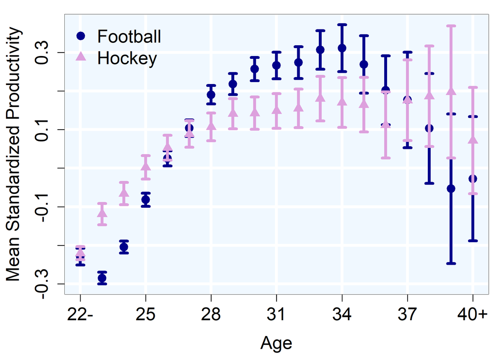

## Worker Productivity in Sports

8. $\dfrac{\delta (Salary)}{\delta \upsilon} \gtrless 0$?
9. Salary cap ($\approx$ **mean revenue**) per worker: hockey ($h$) = $3.82M; football ($f$) $6.21M
   - $\dfrac{\delta (Salary_f)}{\delta \upsilon_f} \gtrless \dfrac{\delta (Salary_h)}{\delta \upsilon_h}$?
   - $Mean(Salary_f) \gtrless Mean(Salary_h)$
   - $Median(Salary_f) \gtrless Median(Salary_h)$

## Worker Productivity in Sports

10. Thinking like an economist, **define “superstar” effects**.
11. In which **sport** are “superstar” effects more likely to appear: hockey or football?
    - Hint: Hockey has 6 players on the ice per team. Rinks are 200 $\times$ 85ft. Football has 11 players per team. Fields are 360 $\times$ 160ft.

## Musical Interlude

[video not shown]

## Worker Productivity in Sports

### Productivity and Salary (Q. 8, 9a & 11)

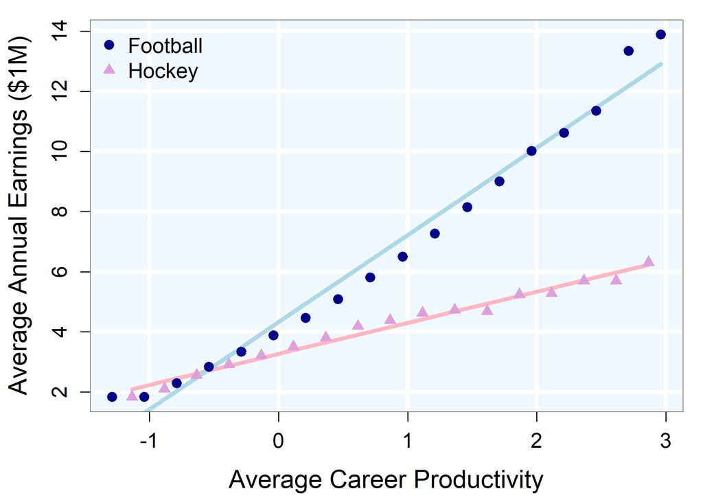

## Worker Productivity in Sports

### Salary Distribution (9b & 9c)

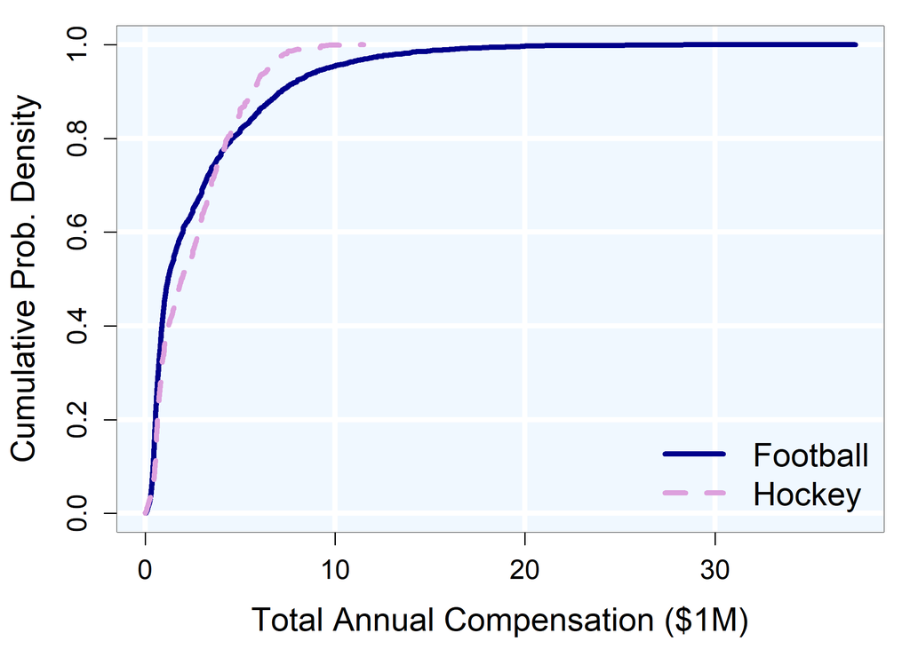

## Worker Productivity in Sports

### Distribution of Productivity by Sport (Q. 11 hint)

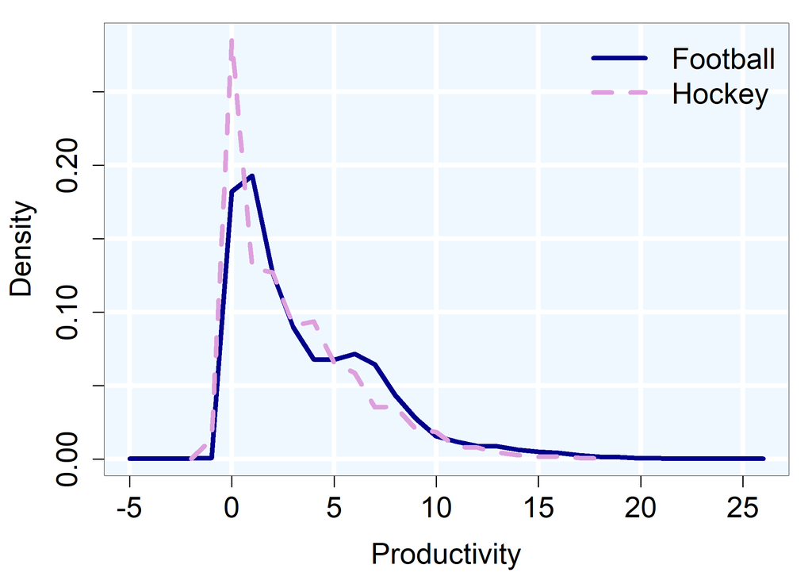

## Health Concerns in Sports

12. Which specific **injury type** is of greatest concern to workers in violent collision sports?
    - Are fears about this injury type becoming **more or less salient** over time?
    - Hint: what disease has recently ($\leq$ 20 years) become synonymous with affecting these athletes?
13. Define, using economic theory, **two ways these health risks affect wages**.
    - Do these ways **increase or decrease** wages? Is the prediction theoretically ambiguous?

## Musical Interlude

[video not shown]

## Health Concerns in Sports

### Timeline of CTE Diagnoses (Q. 12)

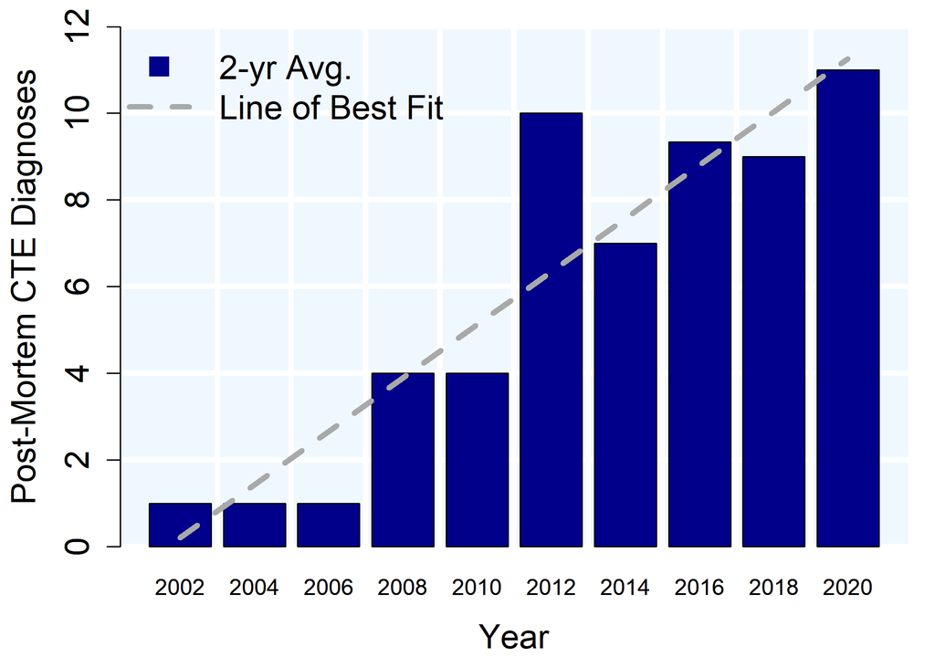

What is CTE?

## Health Concerns in Sports

### Google Trends Timeline (Q. 12a)

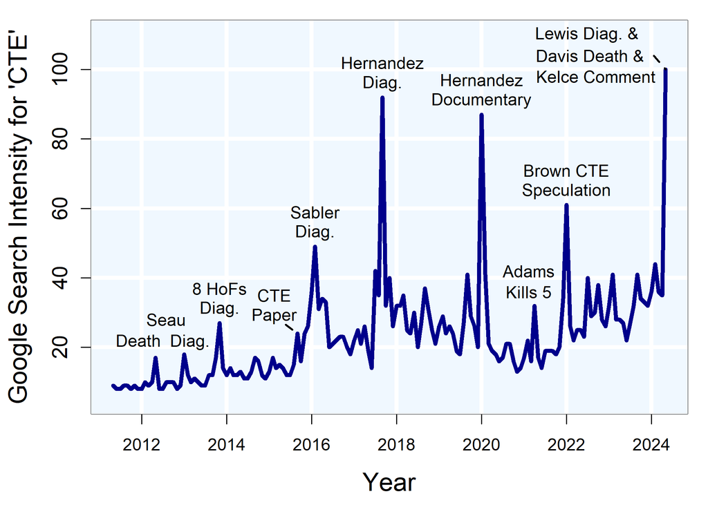

## Theoretical Framework

### Wokrers’ Maximize Utility

$$U_i = \sum_{t=T_0}^{T} \delta^{t-T_0} \left( d_{ist} \cdot \omega_{ist} + (1 - d_{ist}) \cdot \eta_{ist}
\right)$$

- $U_i$ = utility of individual $i$ over the periods from $t$ to $T$
- $\delta$ = discount factor; reflects time preferences; $0 < \delta < 1$,
- $d_{ist} \in \{0, 1\}$; whether employed in sports
- $\omega_{ist}$ = sport wage
- $\eta_{ist}$ = non-sport wage

## Theoretical Framework

### Non-Sport Wages

$$\eta_{ist} = \mu_i - \theta_{ist}$$

- $\mu$: worker’s human capital value
- $\theta$: reduction in working years due to physical toll from violent sports

$$\theta_{ist} = \gamma_{st} + \epsilon_{ist}$$
- $\gamma$ = known (“inherent”) dangers of the sport

- Full-information of workplace safety $\implies E[\epsilon] = 0$

## Theoretical Framework

### Sport Wages

$$\omega_{ist} = \rho_{st} \cdot \upsilon_{ist} + \beta_{ist} \cdot \theta_{ist}$$

- $\rho$ = market demand
- $\upsilon$ = value of the marginal product of labor (relative to replacement worker)
- $\beta$ = workers’ bargaining power

$$\beta_{ist} = \mu_i + \pi_{st} \cdot \upsilon_{ist}$$
- $\pi$ = strength of collective bargaining agreement

## Theoretical Framework

### Predictions: Full Information

- Workers will remain working in sports if $\omega_{ist} \geq \eta_{ist}$
- **Changes** in the decision to remain in sports:

$$\Delta_{it} (\upsilon_{ist} + \epsilon_{ist} \cdot (\upsilon_{ist} + 1)) \geq 0$$

- If $E[\epsilon]=0$, then remain so long as productivity increases:

$$\Delta_{it}( \upsilon_{ist}) \geq 0$$

Change Operator

## Theoretical Framework

### Predictions: Imperfect Information

- Workers will remain working in sports if $\omega_{ist} \geq \eta_{ist}$

$$\Delta_{it} (\upsilon_{ist} + \epsilon_{ist} \cdot (\upsilon_{ist} + 1)) \geq 0$$

- If $E[\epsilon] \neq 0$, then remaining depends upon changes in productivity ($\Delta p \lessgtr -1$)
  - Those with **declining productivity** are more likely to **exit**; cannot internalize risk into wages
  - Those with **rising productivity** are more likely to **stay**; internalize risk into wages (aided by exit of colleagues with declining productivity)

## Findings

- Athletes with a former teammate who died of CTE are 2.2-4.0 percentage points (8-23%) **more likely to retire**.
  - Mechanisms: familiarity, recency, opportunity costs, wage flexibility
  - Placebo: no effect for non-safety-related deaths
  - Treated athletes exhibit higher risk sensitivity, opting for larger signing bonuses and shorter contracts at lower salaries.
- “Treated” workers **value this health shock disamenity at $6M** and need a $1M raise to remain indifferent to exiting.

## Results

### Peer Health Shocks & Retirement: Football

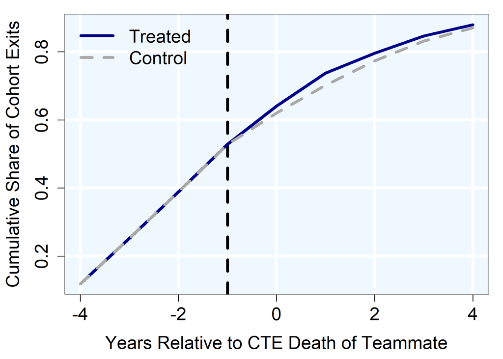

## Results

### Peer Health Shocks & Retirement: Hockey

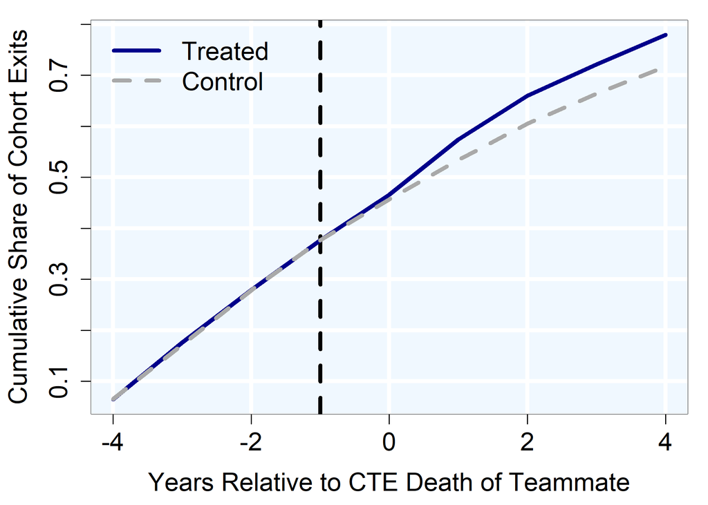

## Results

### Event Studies (by Sport)

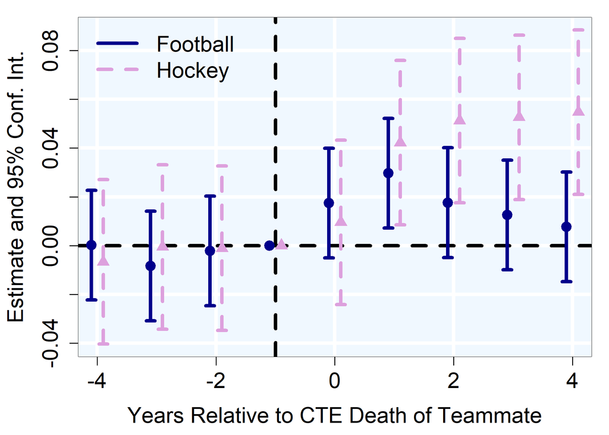

## Results

### Peer Health Shocks & Retirement (by Time as Teammates)

| Dependent Variable: Model: | $\mathbb{1}$(Exit) * 100 (1) | $\mathbb{1}$(Exit) * 100 (2) | $\mathbb{1}$(Exit) * 100 (3) |  |
| --- | --- | --- | --- | --- |
| **Panel A (Time as Teammates)** |  |  |  |  |
| CTE (Post) x Teammate | 2.53*** | 4.30*** | 4.67*** |  |
|  | (0.80) | (1.22) | (1.69) |  |
| Pre-Treatment Mean | 29.03 | 25.69 | 24.87 |  |
| % Change | 0.09 | 0.17 | 0.19 |  |
| Observations | 229,833 | 218,853 | 215,226 |  |
| Mean Pre-Treatment Age | 27.75 | 28.59 | 29.31 |  |
| Length of Time Teammates ($L$): | $L \geq 1$ | $L \geq 2$ | $L \geq 3$ |  |

Treatment Effects by Age

## Hypothesis II

### Recency of Treatment Matters

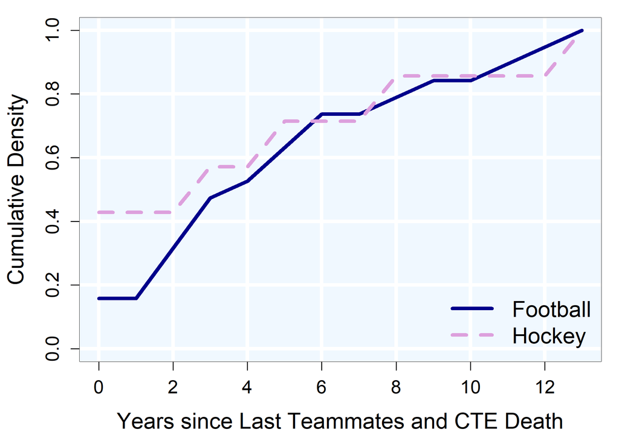

## Results

### Peer Health Shocks & Retirement (Recency of Treatment)

| Dependent Variable: Model: | $\mathbb{1}$(Exit) * 100 (1) | $\mathbb{1}$(Exit) * 100 (2) | $\mathbb{1}$(Exit) * 100 (3) |  |
| --- | --- | --- | --- | --- |
| **Panel A (Recency of Treatment)** |  |  |  |  |
| CTE (Post) x Teammate | 3.14** | 1.78* | 1.91** |  |
|  | (1.45) | (0.96) | (0.88) |  |
| Pre-Treatment Mean | 10.45 | 22.27 | 28.29 |  |
| % Change | 0.3 | 0.08 | 0.07 |  |
| Observations | 95,049 | 202,824 | 219,366 |  |
| Recency of Treatment (D): | $D \leq 2$ | $D \leq 4$ | $D \leq 6$ |  |

## Results

### Peer Health Shocks & Retirements (Recency & 3+ Years Teammates)

| Dependent Variable: Model: | $\mathbb{1}$(Exit) * 100 (1) | $\mathbb{1}$(Exit) * 100 (2) | $\mathbb{1}$(Exit) * 100 (3) |  |
| --- | --- | --- | --- | --- |
| **Panel B (Recency & 3+ Years Teammates)** |  |  |  |  |
| CTE (Post) x Teammate | 7.22* | 4.62* | 3.81* |  |
|  | (4.05) | (2.65) | (2.29) |  |
| Pre-Treatment Mean | 10.45 | 22.27 | 28.29 |  |
| % Change | 0.69 | 0.21 | 0.13 |  |
| Observations | 39,231 | 68,256 | 73,035 |  |
| Recency of Treatment (D): | $D \leq 2$ | $D \leq 4$ | $D \leq 6$ |  |

## Results

### Peer Deaths & Retirement: A Placebo Test

| Dependent Variable: Model: | $\mathbb{1}$(Exit) * 100 (1) | $\mathbb{1}$(Exit) * 100 (2) |
| --- | --- | --- |
| Car Accident (Post) x Teammate | -0.01 |  |
|  | (0.01) |  |
| Disease (Post) x Teammate |  | 0.00 |
|  |  | (0.01) |
| Mean of Dep. | 0.19 | 0.19 |
| % Change | -0.06 | 0.00 |
| Observations | 95,533 | 70,891 |

## Hypothesis III

### Bargaining Power & Wage Flexibility Matter

- The collective bargaining agreement covering hockey players **fully guarantees salaries** which comes at the expense of:
  - highly restrictive salary caps (limits on the sum of labor costs)
  - escrow payments (withheld salary; dependent upon league revenues)
- Salary cap per worker in 2024:
  - NFL $\approx \$6.21M$ per worker
  - NHL $\approx \$3.82M$ per worker

## Contract Data

### Name that…

[figure not shown]

## Contract Data

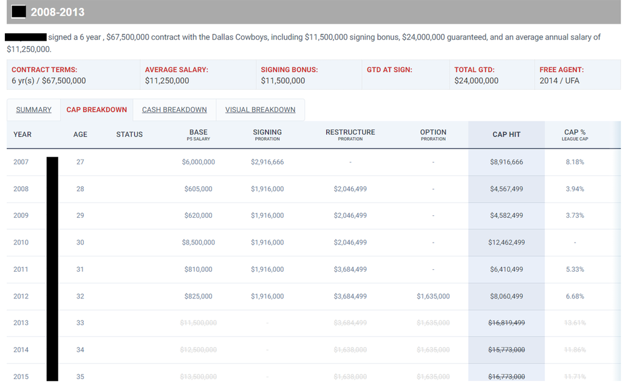

## Results

### Peer Health Shocks & Retirement (by Opportunity Cost)

| Dependent Variable: Sample: Model: | $\mathbb{1}$(Exit) * 100 Full (1) | $\mathbb{1}$(Exit) * 100 Full (2) | $\mathbb{1}$(Exit) * 100 Hockey (3) | $\mathbb{1}$(Exit) * 100 Football (4) |
| --- | --- | --- | --- | --- |
| *CTE (Post) x Teammate* | 3.59** | 2.48* | 1.53 | 4.08** |
|  | (1.45) | (1.46) | (1.41) | (1.88) |
| *$sinh^{-1}$(Opp. Cost)* | -0.48*** | -0.06*** | -0.09*** | -0.02 |
|  | (0.01) | (0.01) | (0.01) | (0.02) |
| *CTE (Post) x Teammate x $sinh^{-1}$(Opp. Cost)* | -0.37*** | -0.32*** | -0.06 | -0.52*** |
|  | (0.09) | (0.09) | (0.08) | (0.12) |
| Controls: Ct. Total & Length |  | $\checkmark$ | $\checkmark$ | $\checkmark$ |
| Observations | 131,424 | 131,424 | 18,679 | 112,745 |

## Results

### Back-of-the-Envelope Calculation: Compensation and Indifference

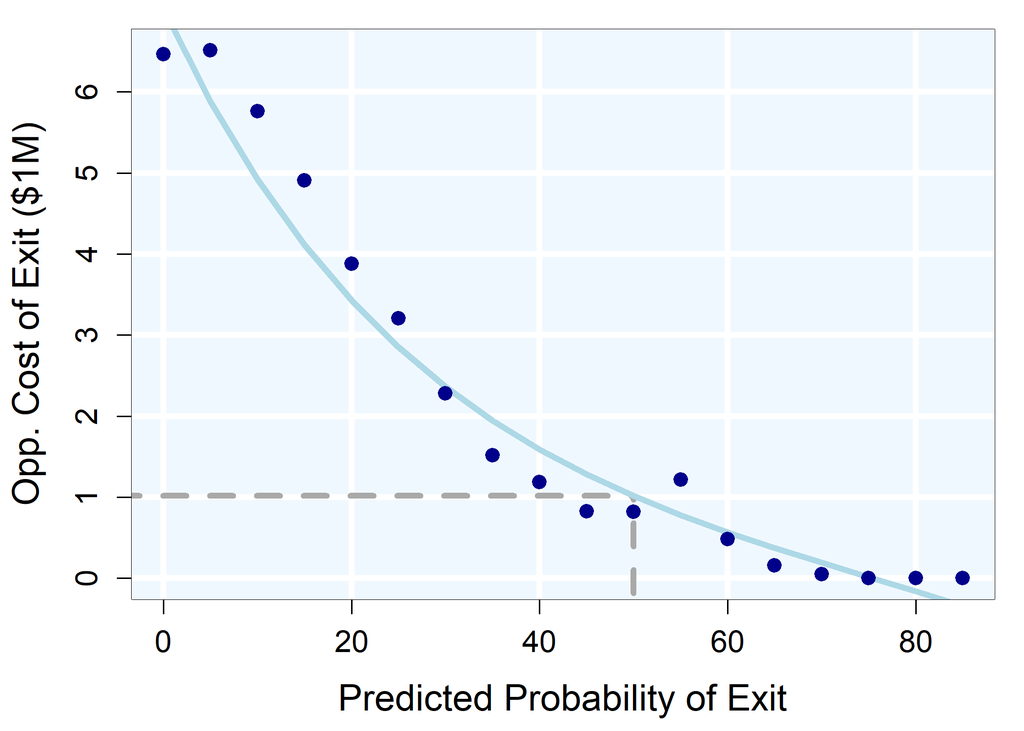

## Conclusion

- I find that workers labor supply is highly elastic with respect to peer health shocks, even in environments where these **risks are widely known** and highly discussed.
  - Familiarity, recency and wage flexibility help explain this finding.
- These findings indicate that **individuals significantly underestimate the utility loss associated with risky behaviors** even in settings where such risks are widely known and discussed.
  - Suggests that public safety policies can provide complementary benefits.

## Thank you!

joshua.martin@vanderbilt.edu

[joshmartinecon.github.io](https://joshmartinecon.github.io/)

[figure not shown]

: JoshMartinEcon

“*Let us suppose that …[a great, distant empire], with all its myriads of inhabitants, was suddenly swallowed up by an earthquake, and let us consider how a man of humanity […], who had no sort of connection with that part of the world, would be affected upon receiving intelligence of this dreadful calamity. He would, I imagine, first of all, express very strongly his sorrow for the misfortune of that unhappy people, he would make many melancholy reflections upon the precariousness of human life, and the vanity of all the labours of man, which could thus be annihilated in a moment…*

*And when all this fine philosophy was over, when all these humane sentiments had been once fairly expressed, he would pursue his business or his pleasure, take his repose or his diversion, with the same ease and tranquillity, as if no such accident had happened. The most frivolous disaster which could befall himself would occasion a more real disturbance.*

*If he was to lose his little finger to-morrow, he would not sleep to-night; but, **provided he never saw them, he will snore with the most profound security over the ruin of a hundred millions of his brethren**, and the destruction of that immense multitude seems plainly an object less interesting to him, than this paltry misfortune of his own.”*

- Adam Smith, *The Theory of Moral Sentiments*

## Appendix

### Change Operator

- Unit fixed-effects: $\Delta X_i = X_{it} - \frac{1}{T} \sum_{\tau = 1}^T x_{i \tau}$
- Time fixed-effects: $\Delta X_i = X_{it} - \frac{1}{I} \sum_{\iota = 1}^I x_{\iota t}$
- For notational simplicity, I denote unit and time fixed-effects as $\Delta_i$ and $\Delta_t$ respectively.

Back

## Appendix

### CTE

- CTE is an **irreversible neurodegenerative condition** that arises from repeated head impacts over extended periods.
  - Symptoms: motor impairments, difficulties regulating emotion, nerve pain, and dementia, often presenting as having advanced Parkinson’s and Alzheimer’s disease.
  - Treatment: symptom management
  - Age profile: 20s - 80s
  - Diagnosis: post-mortem; analysis of brain tissue

## Appendix

### CTE

- CTE has become synonymous with **violent collision sports**, especially American football.
  - Two published academic papers identified the condition in former NFL players (Bennet I. Omalu et al. 2005; Bennet I. Omalu et al. 2006).
- Before the term “CTE,” post-concussive symptoms in athletes were referred to as having one’s “bell rung,” being “**punch drunk**,” or “shell shocked.”
  - These terms implied rare, worst-case outcomes experienced by reckless individuals, with transitory effects.

## Appendix

### CTE

- All athletes diagnosed with CTE from 2005-2008 shared **numerous common traits**: long professional careers, disproportionate exposure to repeated head trauma, and violent styles of play.
- This changed in 2009 with the discovery of CTE in Chris Henry.
  - The collision-averse Henry had played competitive football for **fewer than ten years** before he died at age 26.
- In 14 months in 2010-2011, **4 hockey players** (3 of whom were still active professionals) died and were diagnosed with CTE at the ages of 45, 35, 28, and 27. Back

## Appendix

### Identifying Variation (Football, Part I)

| Player | Career | Date of Death | Teammates at τ = -4 |
| --- | --- | --- | --- |
| Justin Strzelczyk | 1990-1998 | 9/30/2004 | 61 |
| Shane Dronett | 1992-2001 | 1/21/2009 | 40 |
| Chris Henry | 2005-2009 | 12/17/2009 | 137 |
| Junior Seau | 1990-2012 | 5/2/2012 | 157 |
| Jovan Belcher | 2009-2012 | 12/1/2012 | 116 |
| Paul Oliver | 2008-2011 | 9/24/2013 | 115 |
| Adrian Robinson | 2012-2013 | 5/16/2015 | 115 |

## Appendix

### Identifying Variation (Football, Part II)

| Player | Career | Date of Death | Teammates at τ = -4 |
| --- | --- | --- | --- |
| Tyler Sash | 2011-2012 | 9/8/2015 | 80 |
| Aaron Hernandez | 2010-2012 | 4/19/2017 | 71 |
| Daniel Te’o-Nesheim | 2010-2013 | 10/29/2017 | 117 |
| George Atkinson | 2014-2016 | 12/2/2019 | 117 |
| Max Tuerk | 2017-2017 | 6/20/2020 | 68 |
| Vincent Jackson | 2005-2016 | 2/15/2021 | 92 |
| Phillip Adams | 2010-2015 | 4/8/2021 | 114 |
| Demaryius Thomas | 2010-2019 | 12/9/2021 | 199 |

## Appendix

### Identifying Variation (Hockey)

| Player | Career | Date of Death | Teammates at τ = -4 |
| --- | --- | --- | --- |
| Bob Probert | 1986-2002 | 7/5/2010 | 53 |
| Derek Boogaard | 2006-2011 | 5/13/2011 | 102 |
| Rick Rypien | 2006-2011 | 8/15/2011 | 92 |
| Wade Belak | 1997-2011 | 8/31/2011 | 151 |
| Steve Montador | 2002-2012 | 2/15/2015 | 141 |
| Marek Svatoš | 2004-2011 | 11/4/2016 | 59 |

Back

## Appendix

### Peer Health Shocks & Retirement (by Age)

| Dependent Variable: Model: | $\mathbb{1}$(Exit) * 100 (1) | $\mathbb{1}$(Exit) * 100 (2) | $\mathbb{1}$(Exit) * 100 (3) |  |
| --- | --- | --- | --- | --- |
| **Panel B (Age)** |  |  |  |  |
| CTE (Post) x Teammate | 0.10 | 3.70** | 0.56 |  |
|  | (2.22) | (1.53) | (1.72) |  |
| Pre-Treatment Mean | 10.8 | 17.31 | 36.27 |  |
| % Change | 0.01 | 0.21 | 0.02 |  |
| Observations | 97,794 | 131,022 | 32,643 |  |
| Pre-Treatment Mean Age | 22.36 | 26.03 | 32.25 |  |
| Age Percentile ($P$): | $P < \frac{1}{3}$ | $\frac{1}{3} \leq P < \frac{2}{3}$ | $P \geq \frac{2}{3}$ |  |

Back

## References

Omalu, Bennet I., Steven T. DeKosky, Ryan L. Minster, M. Ilyas Kamboh, Ronald L. Hamilton, and Cyril H. Wecht. 2005. “Chronic Traumatic Encephalopathy in a National Football League Player.” *Neurosurgery* 57 (1): 128–34. https://doi.org/10.1227/01.neu.0000163407.92769.ed.

Omalu, Bennet I, Steven T DeKosky, Ronald L Hamilton, Ryan L Minster, M Ilyas Kamboh, Abdulrezak M Shakir, and Cyril H Wecht. 2006. “Chronic Traumatic Encephalopathy in a National Football League Player: Part II.” *Neurosurgery* 59 (5): 1086–93.